# Homework 3

James Livingstone

10/6/22

You can type text anywhere before, after, or between code chunks.

# 1. Summary Statistics

```r
boilers = read_csv("BOILERS.csv")
boilers %>%
  select(Man_HRs, Capacity, Pressure) %>%
  descr(stats = "common", transpose = T)
```

```
## Descriptive Statistics
## boilers
## N: 36
##
##                     Mean   Std.Dev       Min    Median        Max   N.Valid   Pct.Valid
## -------------- --------- --------- --------- --------- ---------- --------- -----------
##       Capacity    318.47    281.42     30.00    150.00    1089.50     36.00      100.00
##        Man_HRs   4290.75   2702.72   1200.00   3713.00   14791.00     36.00      100.00
##       Pressure    750.61    554.64    250.00    410.00    2170.00     36.00      100.00
```

# 2. Scatterplots

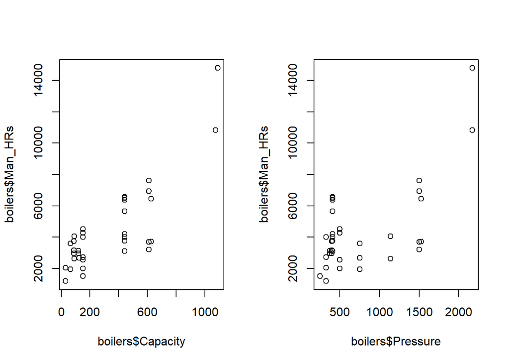

```r
par(mfrow = c(1, 2))
plot(boilers$Capacity, boilers$Man_HRs)
plot(boilers$Pressure, boilers$Man_HRs)
```

Both of these plots look appropriate since they are not non-linear.

# 3. First-Order Multiple Regression Model

```r
main_model = lm(Man_HRs ~ Capacity + Pressure, data = boilers)
summary(main_model)
```

```
##
## Call:
## lm(formula = Man_HRs ~ Capacity + Pressure, data = boilers)
##
## Residuals:
##     Min      1Q  Median      3Q     Max
## -3498.9  -822.2   132.5  1142.8  4287.7
##
## Coefficients:
##              Estimate Std. Error t value Pr(>|t|)
## (Intercept) 1670.5227   443.0166   3.771 0.000642 ***
## Capacity       7.4505     1.4461   5.152 1.18e-05 ***
## Pressure       0.3297     0.7337   0.449 0.656138
## ---
## Signif. codes:  0 '***' 0.001 '**' 0.01 '*' 0.05 '.' 0.1 ' ' 1
##
## Residual standard error: 1559 on 33 degrees of freedom
## Multiple R-squared:  0.6864, Adjusted R-squared:  0.6674
## F-statistic: 36.12 on 2 and 33 DF,  p-value: 4.891e-09
```

# 4. Overall Utility

F = 36.12, p < 0.001 There is enough evidence to conclude that at least one of Capacity or Pressure is significant for predicting man hours.

# 5. Interpret Ra^2

Ra^2 = 0.6674

66.74% of the variability in the man hours is explained by a linear relationship with capacity and pressure.

# 6. Interactions

```r
int_model = lm(Man_HRs ~ Capacity +Pressure + Capacity * Pressure, data = boilers)
summary(int_model)
```

```
##
## Call:
## lm(formula = Man_HRs ~ Capacity + Pressure + Capacity * Pressure,
##     data = boilers)
##
## Residuals:
##      Min       1Q   Median       3Q      Max
## -2964.74  -914.17    53.46  1028.66  2839.99
##
## Coefficients:
##                     Estimate Std. Error t value Pr(>|t|)
## (Intercept)        3.013e+03  7.324e+02   4.114 0.000254 ***
## Capacity           3.786e+00  2.135e+00   1.774 0.085659 .
## Pressure          -1.529e+00  1.083e+00  -1.412 0.167689
## Capacity:Pressure  3.439e-03  1.540e-03   2.233 0.032662 *
## ---
## Signif. codes:  0 '***' 0.001 '**' 0.01 '*' 0.05 '.' 0.1 ' ' 1
##
## Residual standard error: 1472 on 32 degrees of freedom
## Multiple R-squared:  0.7287, Adjusted R-squared:  0.7033
## F-statistic: 28.65 on 3 and 32 DF,  p-value: 3.43e-09
```

# 7. Interaction Interpretation

p = 0.03 I would include this interaction of capacity * pressure because it is significant.

# 8. Estimation of Slope

```r
#Man_HRs = 3013 + 3.786(250) - 1.529(Pressure) + 0.003439(250)(Pressure)

3013 + 3.786 * 250
```

```
## [1] 3959.5
```

```r
#Man_HRs = 3595.5 - (1.529 + 0.003439 * 250 (Pressure))
#Man_HRs = 3959.5 - 0.66925(Pressure)

-1.529 + 0.003439 * 250
```

```
## [1] -0.66925
```

Estimated Change in the man hours for a 1 psi increase in pressure for a boiler drum with a capacity of 250,000 pounds per hour is 3959.5 - 0.66925(Pressure) in which B1 = -0.66925.

# 9. Interpretation of Ra^2

Ra^2 = 0.7033 70.33% of the variability in the man hours is explained by a linear relationship with capacity, pressure, and capacity * pressure.

# 10.Test For Nested Models

```r
simple_model = lm(Man_HRs ~ Capacity, data = boilers)
summary(simple_model)
```

```
##
## Call:
## lm(formula = Man_HRs ~ Capacity, data = boilers)
##
## Residuals:
##     Min      1Q  Median      3Q     Max
## -3396.2  -837.0   209.9  1083.8  4373.8
##
## Coefficients:
##              Estimate Std. Error t value Pr(>|t|)
## (Intercept) 1760.2717   390.7629   4.505 7.46e-05 ***
## Capacity       7.9457     0.9251   8.589 4.93e-10 ***
## ---
## Signif. codes:  0 '***' 0.001 '**' 0.01 '*' 0.05 '.' 0.1 ' ' 1
##
## Residual standard error: 1540 on 34 degrees of freedom
## Multiple R-squared:  0.6845, Adjusted R-squared:  0.6752
## F-statistic: 73.77 on 1 and 34 DF,  p-value: 4.926e-10
```

```r
full_model = lm(Man_HRs ~ Capacity +Pressure + Capacity * Pressure, data = boilers)
summary(full_model)
```

```
##
## Call:
## lm(formula = Man_HRs ~ Capacity + Pressure + Capacity * Pressure,
##     data = boilers)
##
## Residuals:
##      Min       1Q   Median       3Q      Max
## -2964.74  -914.17    53.46  1028.66  2839.99
##
## Coefficients:
##                     Estimate Std. Error t value Pr(>|t|)
## (Intercept)        3.013e+03  7.324e+02   4.114 0.000254 ***
## Capacity           3.786e+00  2.135e+00   1.774 0.085659 .
## Pressure          -1.529e+00  1.083e+00  -1.412 0.167689
## Capacity:Pressure  3.439e-03  1.540e-03   2.233 0.032662 *
## ---
## Signif. codes:  0 '***' 0.001 '**' 0.01 '*' 0.05 '.' 0.1 ' ' 1
##
## Residual standard error: 1472 on 32 degrees of freedom
## Multiple R-squared:  0.7287, Adjusted R-squared:  0.7033
## F-statistic: 28.65 on 3 and 32 DF,  p-value: 3.43e-09
```

```r
anova(simple_model, full_model, test = "F")
```

```
## Analysis of Variance Table
##
## Model 1: Man_HRs ~ Capacity
## Model 2: Man_HRs ~ Capacity + Pressure + Capacity * Pressure
##   Res.Df      RSS Df Sum of Sq      F  Pr(>F)
## 1     34 80657431
## 2     32 69358451  2  11298979 2.6065 0.08939 .
## ---
## Signif. codes:  0 '***' 0.001 '**' 0.01 '*' 0.05 '.' 0.1 ' ' 1
```

F = 2.61, p = 0.089 There is not enough evidence to conclude that there is a significant difference between the simple_model(capacity) and the full_model(interaction).

# 11. Which Model Fits the best?

Though The full_model (containing the interaction between capacity and pressure) and the simple_model(containing only capacity) both have significant p values of less than 0.001, the full_model is the best fit model.

This full_model (interaction model) has the highest Ra^2 value of 70.33% compared to the simple_model with a lesser 67.52%.

# 12. Prediction Interval

```r
#PI
predict(full_model, newdata = data.frame(Capacity = 300, Pressure = 750), interval = "prediction", level = 0.95)
```

```
##        fit      lwr      upr
## 1 3775.664 715.6349 6835.692
```

PI: (715.6349, 6835.692) We are 95% confident that when the boiler capacity is 300,000 pounds per hour and the pressure is 750psi,the man hours required is between 715.63 and 6835.69 hours.